# Crecimiento denso-independiente

Carlos Iván Espinosa

5 de noviembre de 2019

# Crecimiento Poblacional

- ¿De que estamos hablando con crecimiento poblacional?
- Resumen de procesos de: Natalidad, Mortalidad, Inmigración, Emigración
- Cambios en el tamaño de la población

# Crecimiento Denso-independiente

El crecimiento denso-independiente postula que la tasa de incremento *per capita* no tiene dependencia estadística del tamaño de la población.

**Estadísticamente Detectable**

- El detectar una relación significativa, depende de; **el número de observaciones** y el **rango de la variable** predictora

# Crecimiento Geométrico discreto

El crecimiento de mariposas

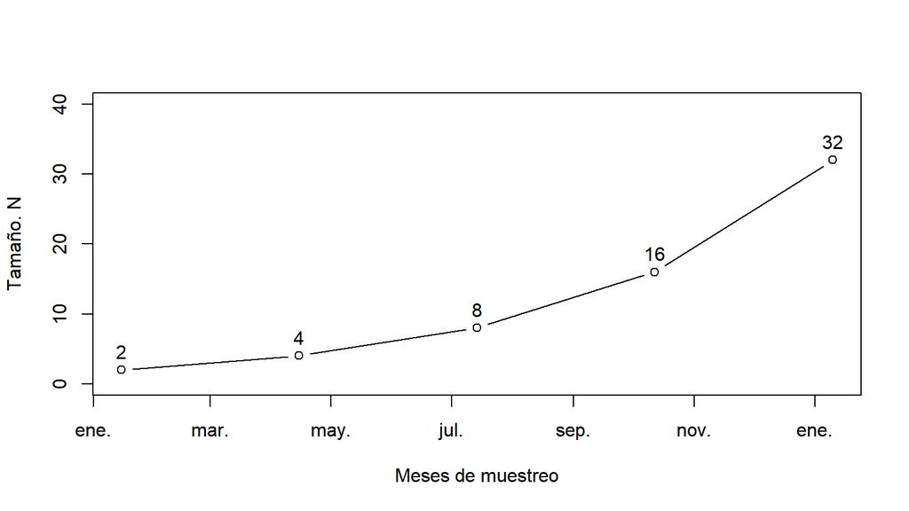

- ¿El crecimiento es igual o ha cambiado?

# La tasa de incremento per capita

- En el primer periodo la población cambió en 2 individuos (tenia dos y llegamos a 4)
- En el segundo periodo llegó a 8 por lo que cambió en 4 individuos.
- Pero, ¿La tasa de incremento cambió?
- Para obtener la tasa de incremento usamos:
  $$tasa = (N_{t+1}/N_t)$$
- Para el primer periodo sería 4/2= 2. La tasa de incremento es **2**

# Calculemos en R

````
```r
tasa <- N[2:5]/N[1:4]
tasa
```

```
## [1] 2 2 2 2
```
````

> Como vemos, nuestra tasa de incremento no varía a lo largo del periodo de muestreo

> Ahora podemos usar la tasa de incremento para saber el tamaño de la población.

# El tamaño de la población en N2

$$N_{abril} = 2 * N_{enero}$$

$$\frac{N_{abril}}{N_{enero}} = 2$$

- Podemos generalizar esta formula como:
  $$N_{t+1} = \lambda * N_t$$
- La tasa de incremento como:
  $$\frac{N_{t+1}}{N_{t}} = \lambda$$

# Proyección de la población

Ahora podemos utilizar la fórmula que derivamos para proyectar la población. Veamos la proyección de la población por cada periodo, en el caso del ejemplo de las mariposas cada 3 meses.

$$N_{abril} = 2 * N_{enero}$$
$$N_{julio} = 2 * N_{abril} = 2 * (2 * N_{enero})$$
$$N_{octubre} = 2 * N_{julio} = 2 * (2 * N_{abril})= 2 * (2 * (2 * N_{enero}))$$

- Podemos calcular el incremento de la población en cualquier momento, multiplicamos la tasa de incremento por tantos ciclos queremos proyectar, para tres ciclos: 2 x 2 x 2 o $2^3$. Elevamos la tasa a la cantidad de ciclos que queremos proyectar la población.
- Generalizamos como: **$N_{t+1} = \lambda^t * N_t$**

# Proyectar la población

Si el ciclo de las mariposas es es 3 meses, proyecte el tamaño de la población a tres años. La población inicial es de 2 individuos.

- ¿Cuántos individuos tendrémos en 3 años?

# Proyectar la población en R

```r
# hacemos una función para calcular el tamaño de la población
crec <- function(lambda, t, N){
          N <- lambda^t * N
       return(N)
}

crec(2,12,2)
```

```
## [1] 8192
```

- ¿Coincide con su proyección?

# Efectos del tamaño inicial de la población

Nuestra población de mariposas se está duplicando en cada periodo, la magnitud del crecimiento es cada vez mayor, crece de una forma geométrica.

- Una población inicial de 10 individuos incrementa en 10 individuos.
- Una población inicial de 20 individuos incrementa de 20 individuos.
- La magnitud del incremento es diferente dependiendo del tamaño de la población inicial.

# Un Ejemplo

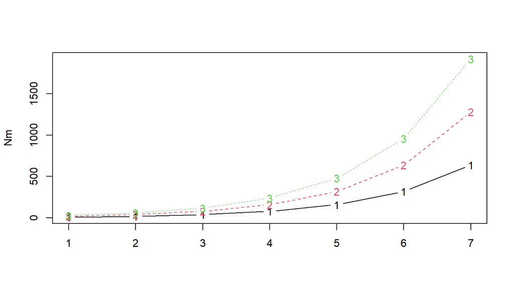

- Estas poblaciones, ¿crecen a una tasa distinta?

# Un Ejemplo (2)

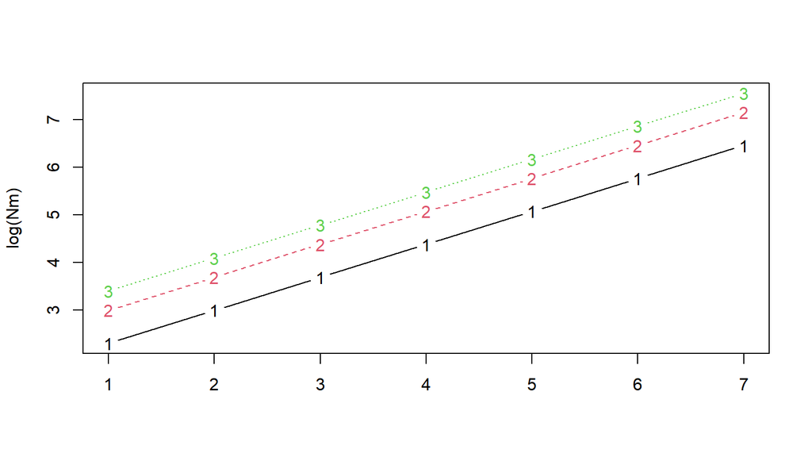

El crecimiento realmente es paralelo, las tres poblaciones están creciendo a una tasa similar. Aunque cambia el intercepto (donde inicia la población) los cambios son lineares en las tres poblaciones.

# Efecto de la tasa de incremento ($\lambda$)

Como hemos visto lambda actúa directamente sobre la población, por lo que los cambios en la tasa *per capita* tienen un fuerte efecto sobre el crecimiento de la población.

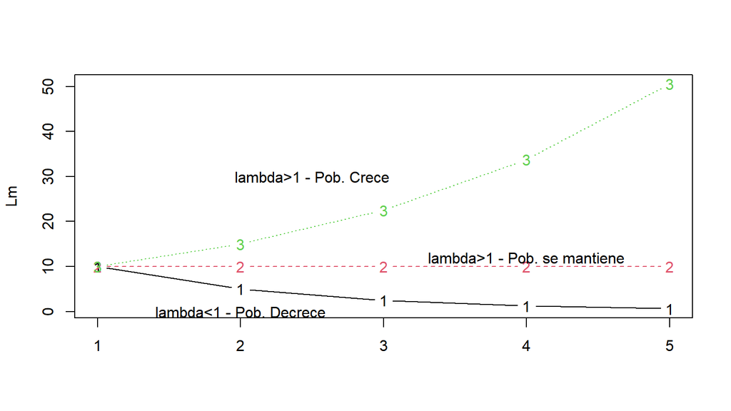

# Tasa promedio de crecimiento

- ¿Cuál sería la tasa de incremento de una población de ninfálidos?
- 100, 50,75
- ¿Cuál tasa usamos para el modelo?
- Podemos usar el valor medio de los diferentes periodos. Intentemos calcular el crecimiento.

# Ejemplo en R

```r
#Nuestros datos
ninfalidos <- c(100, 50, 75)

#obtengamos lambda
ninL <- ninfalidos[2:3]/ninfalidos[1:2]
ninL
```

```
## [1] 0.5 1.5
```

```r
#obtenemos la media
xL <- mean(ninL)

#usamos nuestra función
crec(lambda = xL, t = 3,N = 100)
```

```
## [1] 100
```

# La media geométrica

Como vemos la media aritmética no es la mejor medida para poder proyectar la comunidad. Una medida que se ajusta mejor es la media geométrica.

```r
#calculamos la media aritmética
xgL <- prod(ninL)^(1/3)

#usamos nuestra función
crec(lambda = xgL, t = 3,N = 100)
```

```
## [1] 75
```

# Ejercicio 1

Resolver el [ejercicio 1](https://ciespinosa.github.io/CrecimientoDensoIndependiente/)

# Crecimiento exponencial continuo

El modelo geométrico propone el crecimiento de la población como una serie de eventos reproductivos, así cada ciclo la población se reproduce en un único evento.

- ¿Realmente las poblaciones crecen a saltos?

# Ejemplo

Imaginemos que ponemos en una caja petri 1000 individuos de *E. coli* y al siguiente día contamos la cantidad de bacterias y tenemos $10^10$ bacterias, eso implicaría que las bacterias tienen una tasa de incremento (lambda) de $10^7$ por día.

Pero las bacterias están reproduciéndose continuamente y de forma asíncrona.

# Incremento continuo

Jacob Bernulli (1654), se dio cuenta que el crecimiento geométrico depende de la periodicidad que asumimos que ocurren los ciclos reproductivos. Una tasa de $\lambda = 1.5$ anualmente, implicaría que la población incremente el 50% cada año, por lo que su **tasa de incremento discreto** es $r_d = 0.5$.

Con dos eventos la tasa debería ser dividida para 2 elevado para el número de ciclos.

$$N_1 = N_0(1+0.5)$$
$$N_1 = N_0(1+05/2)^2$$

Podríamos generalizar como:

$$N1 = N_0\biggl(1+ \frac{r_d}{n}\biggr)^n$$
$$\frac{N1}{N0} = \biggl(1+ \frac{r_d}{n}\biggr)^n$$

# Periodos infinitos

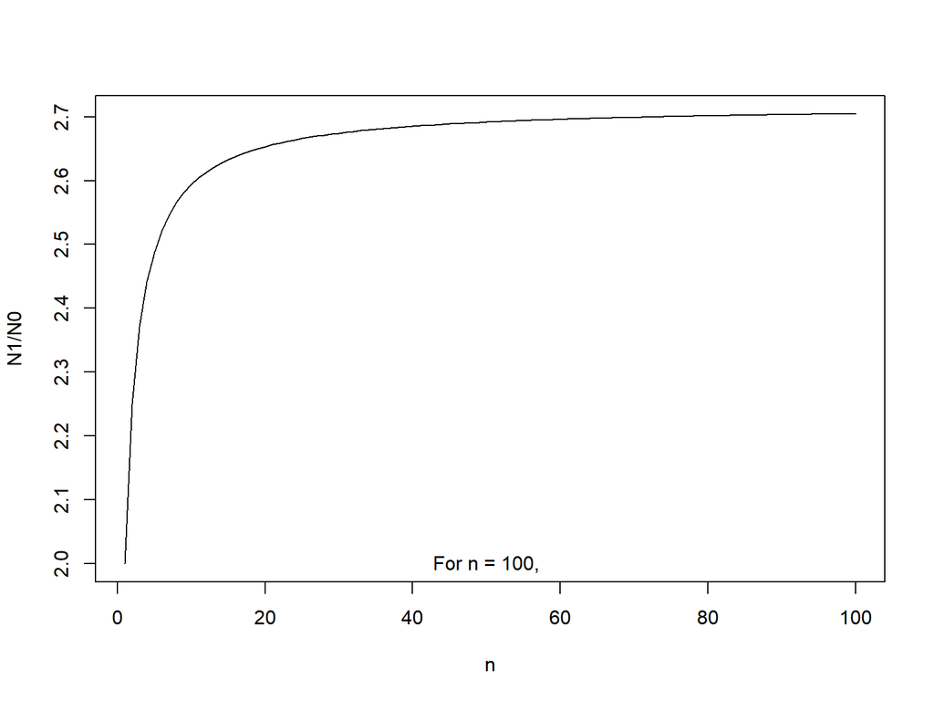

```r
n <- 1:100 #entre 1 y 100 periodos en el año
N0 <- 1 #población inicial de 1
rd <- 1 #tasa de incremento discreto

#Calculamos el tamaño de la población
N1 <- N0 * (1 + rd/n)^n

#Graficamos los datos
plot(n, N1/N0, type = "l")
text(50, 2, "For n = 100,")
text(50, 1.6, bquote((1 + frac("r"["d"], "n"))^"n" == + .(round(N1[101]/N0, 3))))
```

# La constante e

Como vemos cuando incrementamos el número de eventos reproductivos llegamos a una constante que es 2.718.

El crecimiento exponencial es:

$$N_t = N_0e^{rt}$$
en este caso r es la tasa intrínseca de crecimiento.

# Ajustando el modelo

Veamos como podemos ajustar un modelo de crecimiento exponencial continuo.

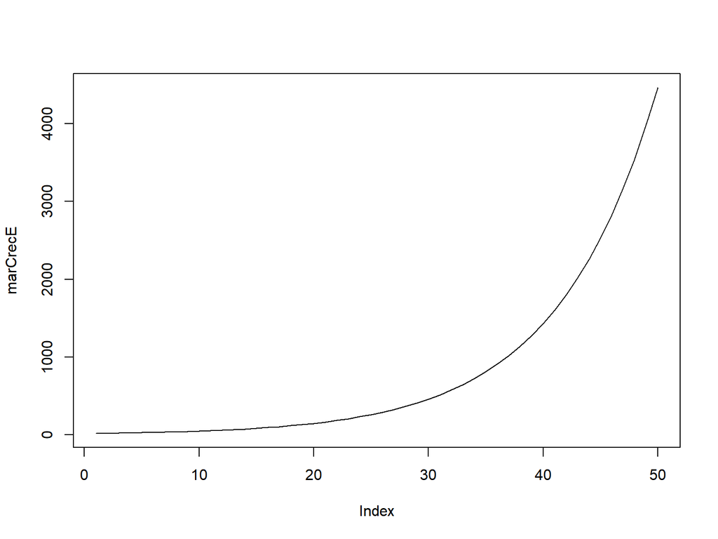

```r
#nuestra población
mariposas <- c(10, 25, 89, 160, 312)

#obtenemos lambda
lamM <- mariposas[2:5]/mariposas[1:4]

#convertimos lambda en r
rM <- log(lamM)

##Hacemos una función de crecimiento exponencial
crecE <- function(N0,r,t ){
  N <- N0*exp(r*t)
  return(N)
}

#obtenemos la media aritmética de r
rMx <- prod(rM)^1/4

#proyectamos la población

marCrecE <- crecE(N0=15, r = rMx, t = 1:50)
plot(marCrecE, type="l")
```

# Efecto de r

Como vemos r tiene un efecto sobre el crecimiento, valores superiores a 0 implicarán un incremento de la población, mientras que valores debajo de cero implicarán una reducción de la población.

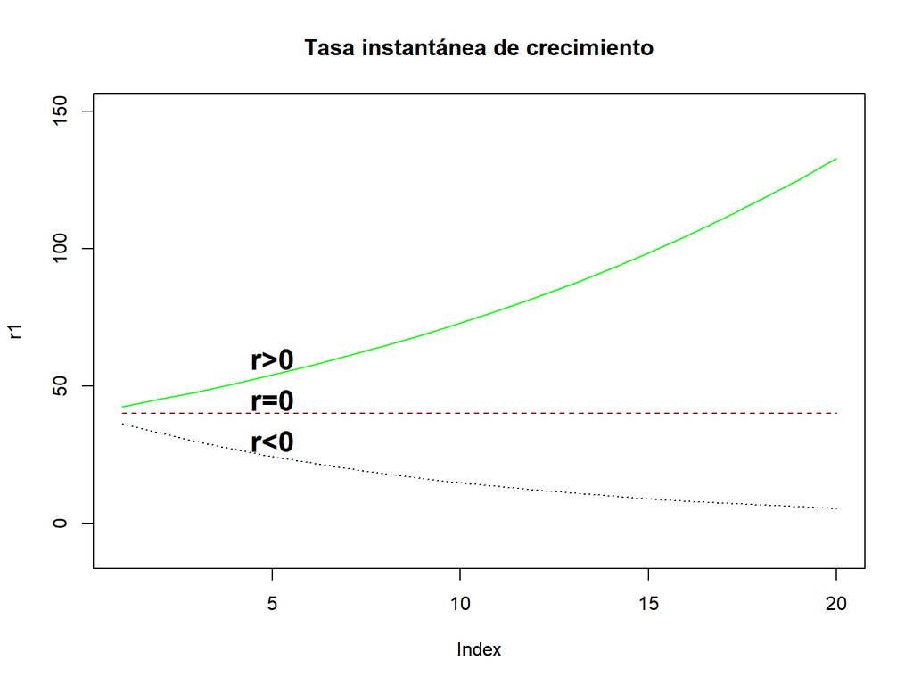

```r
r1 <- crecE(40,0.06,1:20)
r2 <- crecE(40,0,1:20)
r3 <- crecE(40,-0.1,1:20)

plot(r1, type="l", ylim=c(-10,150), col="green", main="Tasa instantánea de crecimiento")
lines(r2, col="darkred", lty=2)
lines(r3, lty=3)

text(5,60, "r>0", font=2, cex=1.5)
text(5,45, "r=0", font=2, cex=1.5)
text(5,30, "r<0", font=2, cex=1.5)
```

# Modelando datos: Simulando la dinámica

Hasta ahora hemos trabajado con modelos deterministas usando una tasa de incremento promedio. Otra aproximación es simular la dinámica de la población con alguna cuantificación de incertidumbre.

Analizar los datos y utilizarlos para calcular parámetros del modelo de forma aleatoria.

# Aleatorizando r

Podríamos utilizar la variación de la tasa de incremento como una medida aleatoria y proyectar la población. Miremos los datos:

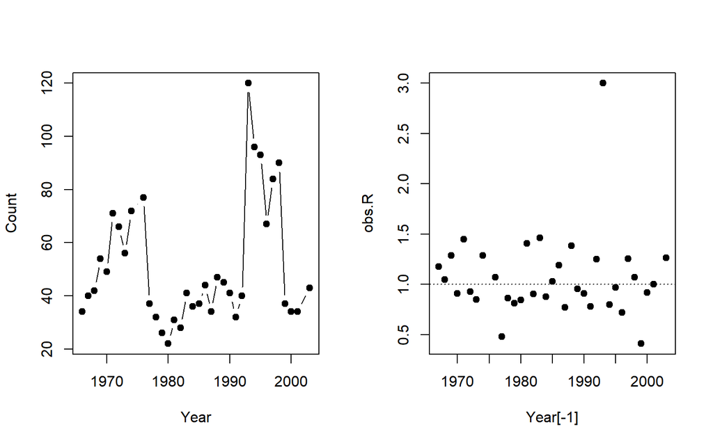

Crecimiento y lambda de Sparrows

```r
par(mfcol=c(1,2))
plot(Year, Count, type="b", pch=19)
obs.R <- Count[-1]/Count[-length(Count)]
plot(Year[-1], obs.R, pch=19)
abline(h = 1, lty = 3)
```

# Variación de lambda

¿Qué pasa con la tasa de crecimiento?

# Vamos a simular

Simularemos el crecimiento de la población a 50 años, pero no utilizaremos una media geométrica de lambda.

```r
years<- 50
set.seed(12)
sim.Rs <- sample(x = obs.R, size = years,
                 replace = TRUE)
```

Ahora tenemos nuestra tasa de incremento aleatoria para cada año.

# La predicción

Generamos un vector vacío para poder poner nuestra predicción.

```r
sim1 <- numeric(years + 1)
sim1[1] <- Count[Year == max(Year)]
for (t in 1:years) {
  sim1[t + 1] <- sim1[t] * sim.Rs[t] }
```

Ahora podemos graficar la población simulada

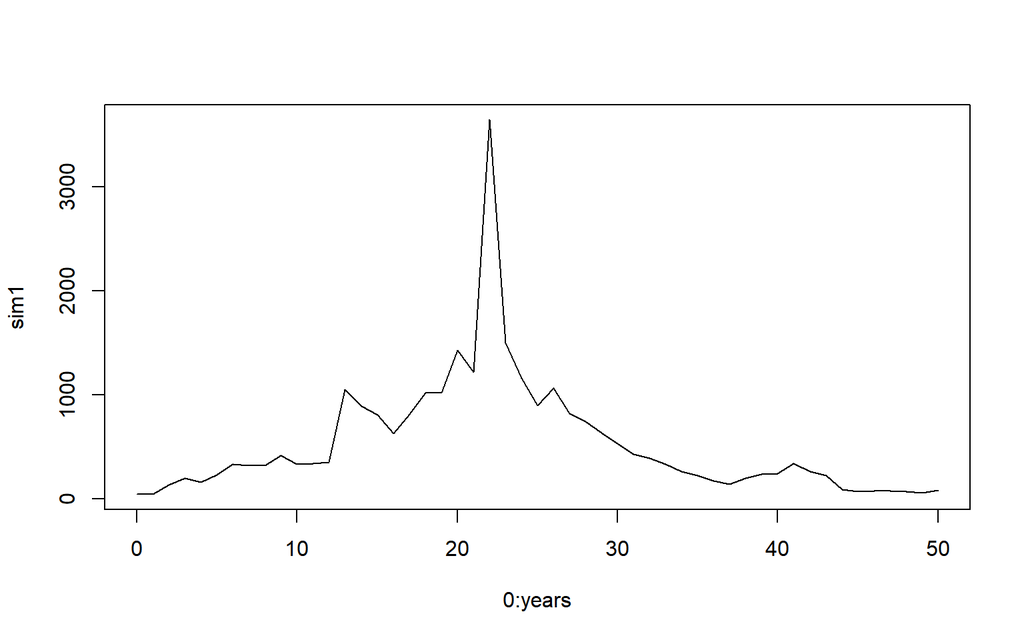

Población simulada con valores aleatorios de lambda

```r
plot(0:years, sim1, type="l")
```

# Simulaciones

Tenemos una población simulada, sin embargo, cada que ejecutamos la función tenemos nuevos datos, para que podamos obtener información de esta simulación debemos generar múltiples corridas.

```r
PopSim <- function(Rs, N0, years = 50, sims = 10) {
              sim.RM = matrix(sample(Rs, size = sims * years, replace = TRUE),
                                    nrow = years, ncol = sims)
             output <- numeric(years + 1)
             output[1] <- N0
             outmat <- sapply(1:sims, function(i) {
                        for (t in 1:years) output[t + 1] <- round(output[t] *
                                                  sim.RM[t, i], 0)
                                          output
                                                 })
                   return(outmat)
                    }
```

# Simulaciones

Ahora, podemos simular la población y solo debemos incluir los datos de lambda (obs.R), el tamaño inicial de la población (N0) y la cantidad de simulaciones.

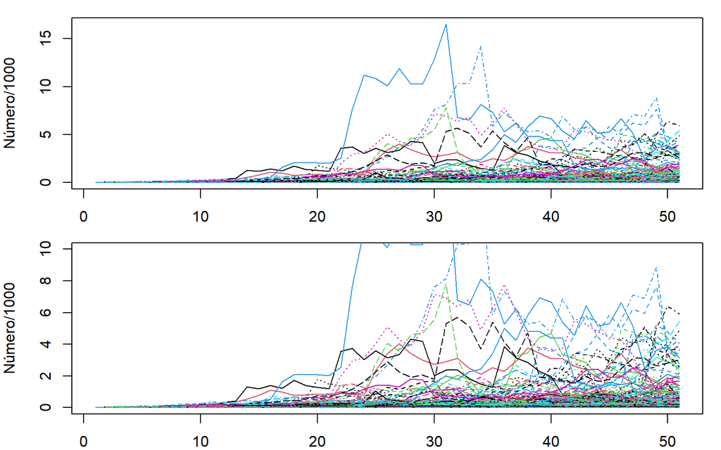

Crecimiento con 1000 simulaciones (arriba). Reducción de la escala de la población (abajo).

```r
par(mfcol=c(2,1), mar=c(2,4,1,1))
output <- PopSim(Rs = obs.R, N0 = 13, sims = 1000)
matplot(output/1000, type="l", ylab="Número/1000")
matplot(output/1000, type="l", ylim=c(0,10), ylab="Número/1000")
```

```r
dim(output)
```

```
## [1]   51 1000
```

# Población resultante

Extraemos el tamaño de la población en el último año2053, para poder analizar la proyección generada de la población.

```r
N.2053 <- output[51, ]
summary(N.2053, digits = 6)
```

```
##    Min. 1st Qu.  Median    Mean 3rd Qu.    Max.
##     0.0     3.0    17.0   170.9    82.0  5936.0
```

# Graficamos

Grafiquemos los datos y veamos su distribución. Adicionamos los límites de un intervalo de confianza del 95%.

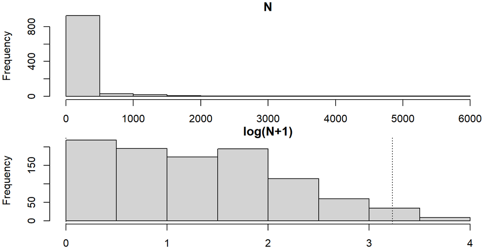

Distribución de las simulaciones de la población en el año 2053

```r
par(mfcol=c(2,1), mar=c(2,4,1,1))
hist(N.2053, main = "N")
hist(log10(N.2053 + 1), main = "log(N+1)")
abline(v = log10(quantile(N.2053, prob = c(0.0275, 0.975))
                                      + 1), lty = 3)
```

# Probabilidad de extinción